# Plate reader growth curves of GAT201 mutants in RPMI media combining NaHCO3 and cAMP

Liz Hughes & Edward Wallace

05/03/2024

# Summary

This experiments tests the effect of sodium bicarbonate (NaHCO3) and cAMP on growth of Cryptococcus neoformans.

Plate reader growth curves of WT KN99-alpha and gat201∆ deletion mutant Madhani in RPMI media with no phenol red.

- 2 Bioreps, 3 Techreps each. One control condition has has 1 Biorep with 3 Techreps
- Grow 5ml culture from colony (1 colony = 1 Biorep) in YPD, 30C, 180 rpm ON.
- Seed at OD 600nm = 0.2 , 200 ul per well.
- Run for 1 day / 24 hours at 37C
- With 2 concentrations of NaHCO3: 0mM, 24mM
- With 2 concentrations of dbcAMP: 0mM (water control), 10 mM; or 10mM sodium butyrate (Nabut) to control for butyrate toxicity as a breakdown product of dbcAMP.

Data in file:

- `20240305_cAMP_Assay.xlsx`

# Set up data frame of nice strain names, colours, styles.

```r
strain_df <- tibble( Strain      = c("KN99-1", "KN99-2", "Gat201(M)", "Gat201(M)-2"),
                     Strain_nice = c("GAT201", "GAT201", "gat201∆m", "gat201∆m"),
                     colour      = c("grey20", "grey20", "darkred", "darkred"))
```

```r
media_df <- tibble( Medium      = as_factor(c("RPMI-N", "RPMI-24", "RPMI-N+W", "RPMI-24+W", "RPMI-N+C", "RPMI-24+C", "RPMI-N+SB", "RPMI-24+SB" )),
                    NaHCO3      = as_factor(c("−", "+", "−", "+", "−", "+", "−", "+" )),
                    cAMP      = as_factor(c("−", "−", "−", "−", "+", "+", "SB", "SB" )),
                    addition      = as_factor(c("H2O", "H2O", "H2O", "H2O", "dbcAMP", "dbcAMP", "Nabut", "Nabut" ))
                    )
```

## Read in the Plate map data from csv file RPMI

Also combine with nice strain names for display.

```r
platemap <-
  here::here("data", "20240305_cAMP_Plate_Setup.csv") %>%
  read_platemap_csv(strain_df = strain_df) %>%
  left_join(media_df, by = "Medium")

head(platemap, n=10)
```

```
## # A tibble: 10 × 10
##    Well  Strain Biorep Techrep Medium Strain_nice colour NaHCO3 cAMP  addition
##    <chr> <chr>   <dbl>   <dbl> <chr>  <chr>       <chr>  <fct>  <fct> <fct>
##  1 A1    <NA>       NA      NA RPMI-N <NA>        <NA>   −      −     H2O
##  2 A2    <NA>       NA      NA RPMI-N <NA>        <NA>   −      −     H2O
##  3 A3    <NA>       NA      NA RPMI-N <NA>        <NA>   −      −     H2O
##  4 A4    <NA>       NA      NA RPMI-N <NA>        <NA>   −      −     H2O
##  5 A5    <NA>       NA      NA RPMI-N <NA>        <NA>   −      −     H2O
##  6 A6    <NA>       NA      NA RPMI-N <NA>        <NA>   −      −     H2O
##  7 A7    <NA>       NA      NA RPMI-N <NA>        <NA>   −      −     H2O
##  8 A8    <NA>       NA      NA RPMI-N <NA>        <NA>   −      −     H2O
##  9 A9    <NA>       NA      NA RPMI-N <NA>        <NA>   −      −     H2O
## 10 A10   <NA>       NA      NA RPMI-N <NA>        <NA>   −      −     H2O
```

# Analysis

## Read in raw data

```r
raw_od <-
  here::here("data", "20240305_cAMP_Assay.xlsx") %>%
  read_platereader_xlsx_magellan()
```

## Reshape data and combine with the plate map, pairing them by Well

```r
annotated_od <-
  reshape_annotate_raw_od(raw_od = raw_od, platemap = platemap)  %>%
  mutate(Well = factor(Well, levels = well_names_96_rowfirst))
```

## Plot ODs from all wells

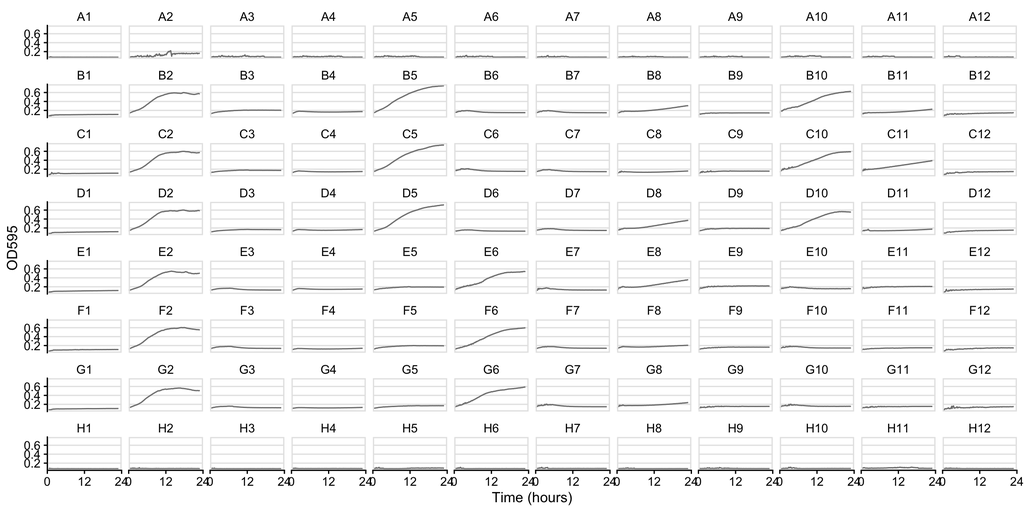

```r
ggplot(data=annotated_od,
       aes(x=Time, y=OD595,  group = Well, colour = Strain)) +
  geom_line() +
  scale_time_hrs(limits = c(0,24)) +
  scale_color_strain(strain_df) +
  facet_wrap(~ Well, ncol = 12)
```

## Plot blank ODs

To find how stable the ODs of the blank wells are.

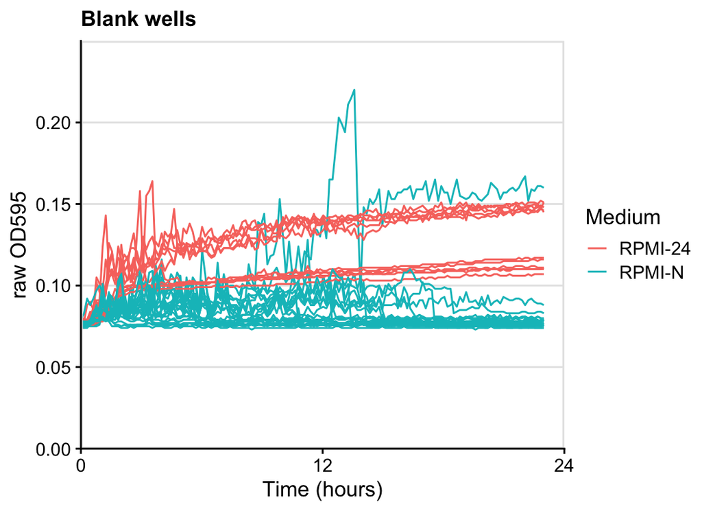

```r
ggplot(data=filter(annotated_od, is.na(Strain)),
       aes(x=Time, y=OD595,  group = Well, colour = Medium)) +
  geom_line() +
  scale_time_hrs(limits = c(0,24)) +
  scale_y_continuous(limits = c(0, 0.25),
                     expand = c(0, 0),
                     breaks = c(0, 0.05, 0.1, 0.15, 0.2)) +
  labs(title = "Blank wells", x="Time (hours)", y="raw OD595")
```

This shows that OD of blank wells is somewhat messy, but within reasonable bounds.

## Calculate median OD for blank wells

```r
blank_od_summary <-
  annotated_od %>%
  dplyr::group_by(Medium) %>%
  summarise_od_fixed(od.name = "OD595",
                     is.na(Strain))

print(blank_od_summary)
```

```
## # A tibble: 2 × 5
## # Groups:   Medium [2]
##   Medium  OD_median OD_mean OD_max OD_min
##   <chr>       <dbl>   <dbl>  <dbl>  <dbl>
## 1 RPMI-24     0.111  0.118   0.164  0.073
## 2 RPMI-N      0.079  0.0838  0.22   0.073
```

```r
blank_od_time <-
  annotated_od %>%
  dplyr::group_by(Medium) %>%
  summarise_od_bytime(od.name = "OD595",
                     is.na(Strain),
                     !is.na(OD595))

print(blank_od_time)
```

[output not shown]

## Subtract blank OD to make corrected OD

```r
normalised_od <-
  annotated_od %>%
  normalise_od_2ways(is.na(Strain))
```

## Plot OD corrected

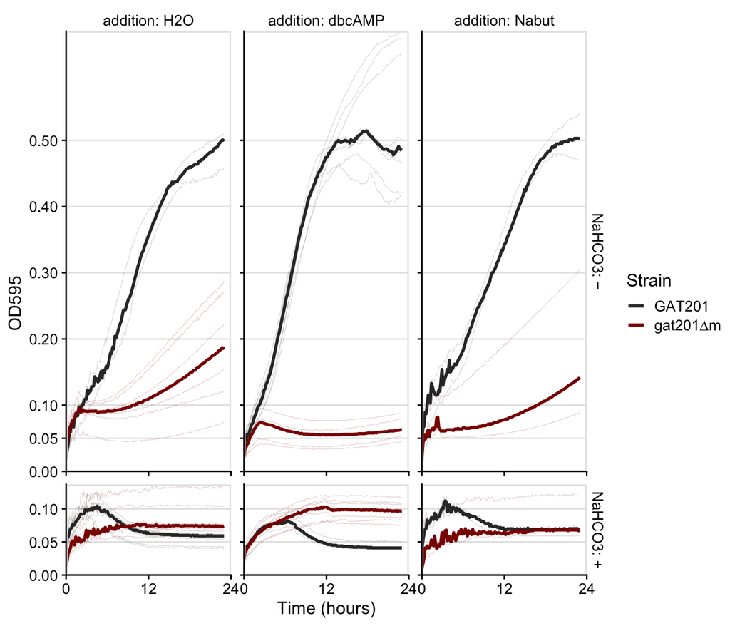

```r
plot <-
  ggplot_growthcurve_summary(data_od = normalised_od %>%
                               filter(!is.na(Strain)),
                             value_od = "OD_corrected_fixed",
                             limits_time = c(0,24),
                             limits_od = NULL,
                             breaks_od = c(0, 0.05, 0.1, 0.2, 0.3, 0.4, 0.5)) +
  scale_color_strain(strain_df) +
  expand_limits(y = c(0, 0.12)) +
  facet_rep_grid(NaHCO3 ~ addition,
                 scales = "free_y",
                 space = "free_y",
                 labeller = label_both)

plot
```

## Same unsmoothed plot for supplementary figure

Conclude that dbcAMP does not qualitatively affect the phenotype of GAT201 affecting growth in a NaHCO3-dependent way.

Sodium butyrate as additional negative control also does not strongly affect growth.

## Plot OD corrected, with smoothing spline

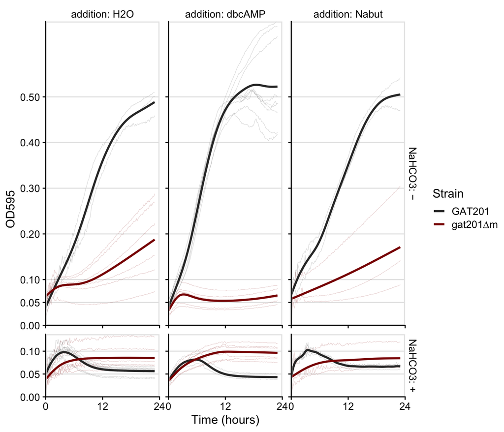

```r
spline_plot <-
  ggplot_growthcurve_spline_pluswells(data_od = normalised_od %>%
                               filter(!is.na(Strain)),
                             value_od = "OD_corrected_fixed",
                             limits_time = c(0,24),
                             limits_od = NULL,
                             breaks_od = c(0, 0.05, 0.1, 0.2, 0.3, 0.4, 0.5)) +
  scale_color_strain(strain_df) +
  expand_limits(y = c(0, 0.12)) +
  facet_rep_grid(NaHCO3 ~ addition,
                 scales = "free_y",
                 space = "free_y",
                 labeller = label_both)

spline_plot
```

```r
ggsave(filename = here::here("results", "fig_growthcurves_NaHCO3_vs_cAMP.png"),
       plot = spline_plot, height = 5, width = 6.5)
```